# EDF 6938 Lecture 4: Introduction to ggplot2

## Two Variable Plots

Let’s start with Categorical and Continuous using some of the grouping we already have. Basic:

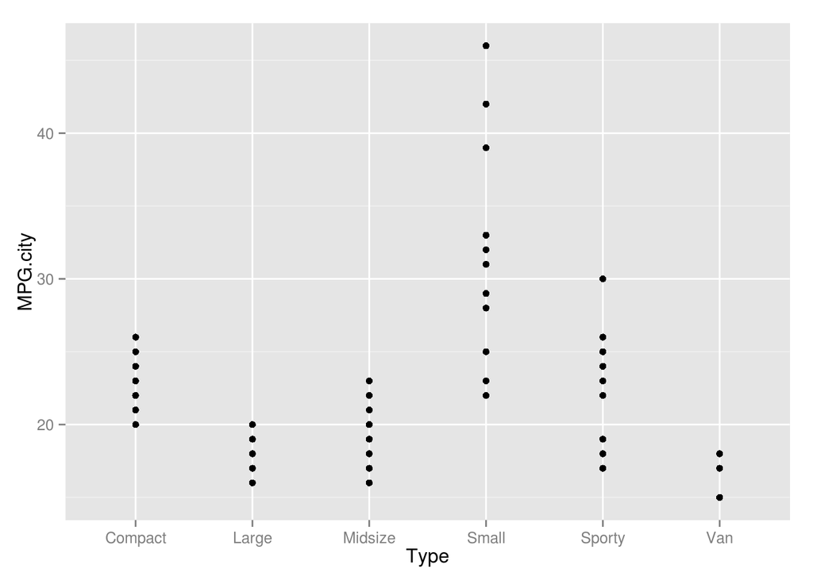

```r
ggplot (Cars93,           ## the data frame
        aes (Type,        ## x axis
             MPG.city)    ## y axis
        ) +
  geom_point()
```

Box and whisker plot:

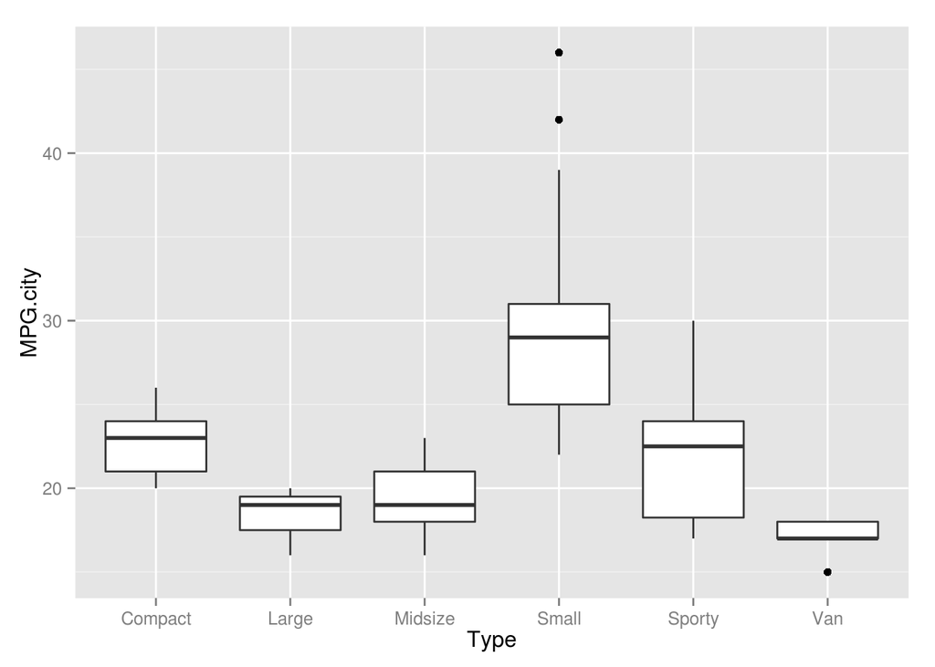

```r
ggplot (Cars93,           ## the data frame
        aes (Type,        ## x axis
             MPG.city)    ## y axis
        ) +
  geom_boxplot()
```

Violin plot – density estimate:

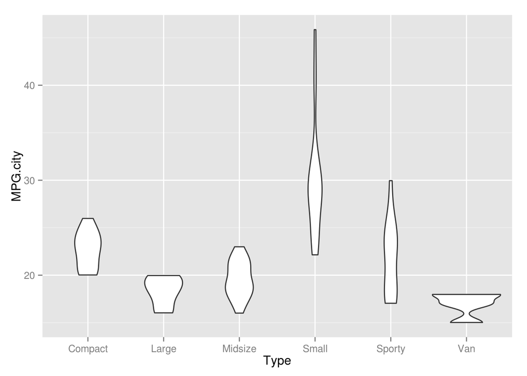

```r
ggplot (Cars93,           ## the data frame
        aes (Type,        ## x axis
             MPG.city)    ## y axis
        ) +
  geom_violin()
```

Violin plot with color for contrast:

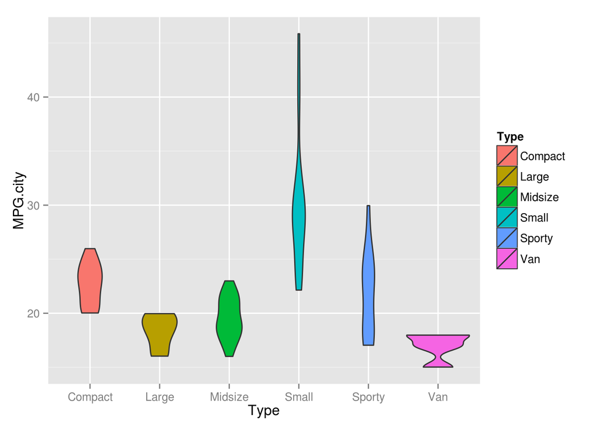

```r
ggplot (Cars93,           ## the data frame
        aes (Type,        ## x axis
             MPG.city)    ## y axis
        ) +
  geom_violin(aes(fill=Type))
```

Let’s add another feature: put the points right on the plot!

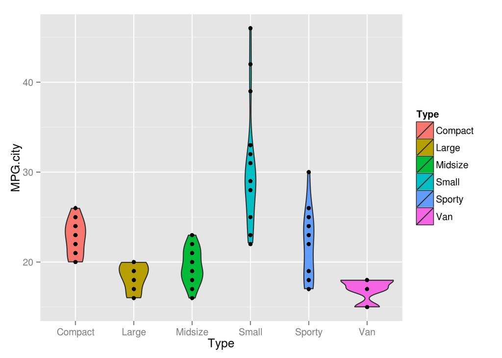

```r
ggplot (Cars93,           ## the data frame
        aes (Type,        ## x axis
             MPG.city)    ## y axis
        ) +
  geom_violin(aes(fill=Type)) + geom_point()
```

Let’s add some more space to the points to get rid of the overlap.

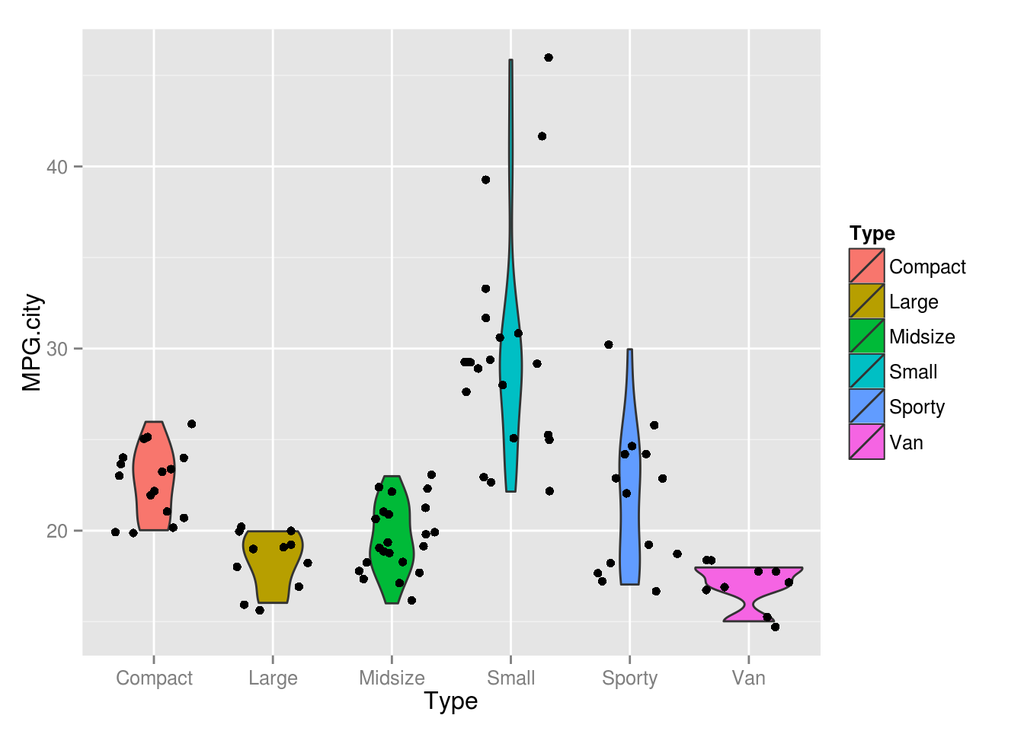

```r
ggplot (Cars93,           ## the data frame
        aes (Type,        ## x axis
             MPG.city)    ## y axis
        ) +
  geom_violin(aes(fill=Type)) + geom_jitter()
```

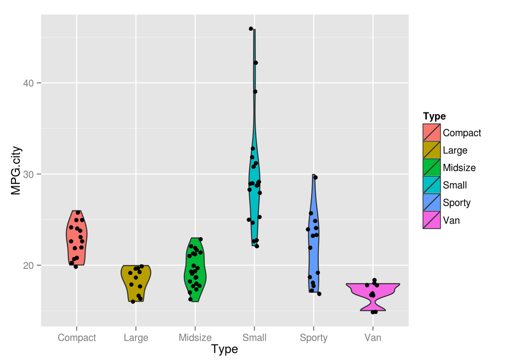

```r
ggplot (Cars93,           ## the data frame
        aes (Type,        ## x axis
             MPG.city)    ## y axis
        ) +
  geom_violin(aes(fill=Type)) + geom_jitter(position = position_jitter(width = .1))
```

## Scatterplots And Beyond

Start simple. And let’s save this to a variable so we don’t have to repeat the same commands.

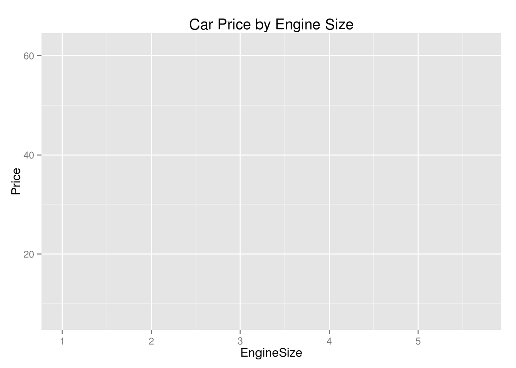

```r
base.two <- ggplot (Cars93, aes (EngineSize, Price)) + ggtitle ("Car Price by Engine Size") + geom_blank()

base.two
```

Let’s add some features to it.

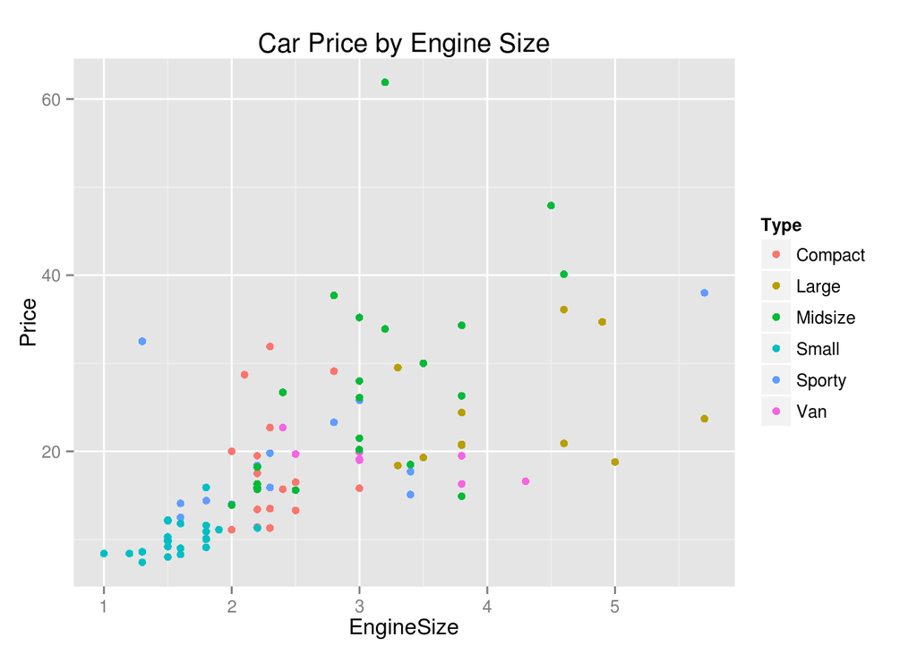

```r
base.two + geom_point(aes(col=Type))
```

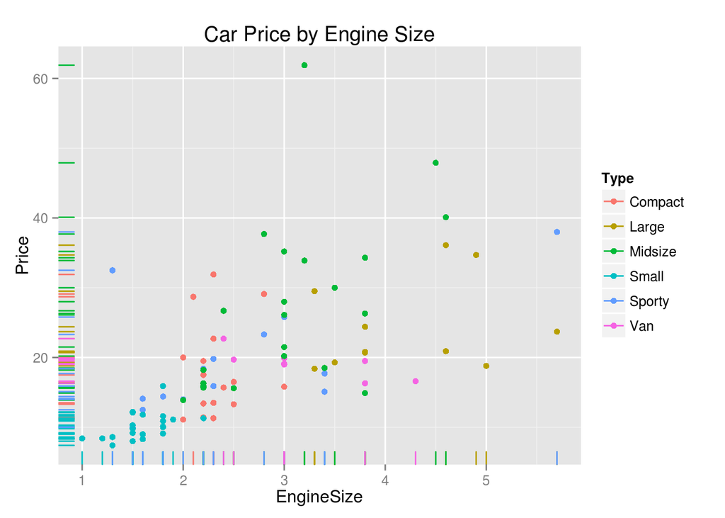

```r
base.two + geom_point(aes(col=Type)) + geom_rug(aes(col=Type))
```

```
## geom_smooth: method="auto" and size of largest group is <1000, so using loess. Use 'method = x' to change the smoothing method.
```

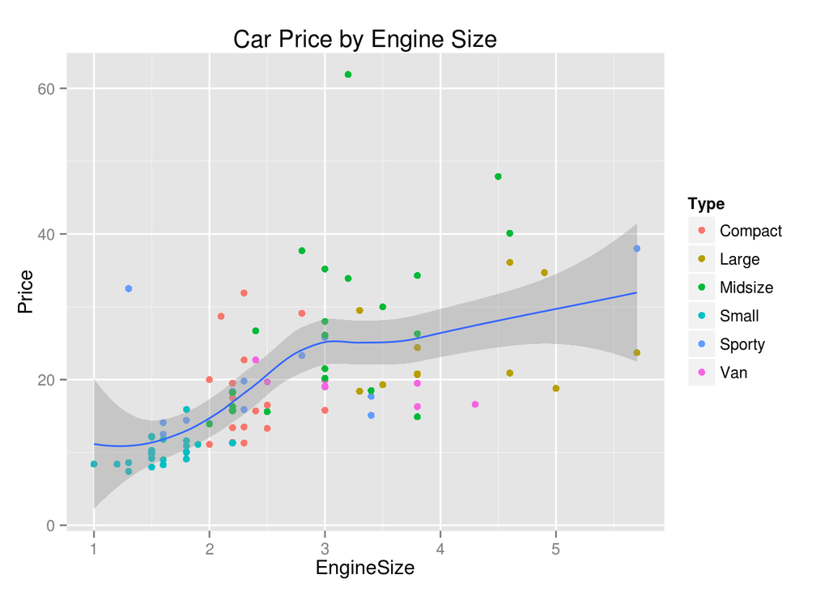

```r
base.two + geom_point(aes(col=Type)) + geom_smooth()
```

```
## geom_smooth: method="auto" and size of largest group is <1000, so using loess. Use 'method = x' to change the smoothing method.
## geom_smooth: method="auto" and size of largest group is <1000, so using loess. Use 'method = x' to change the smoothing method.
## geom_smooth: method="auto" and size of largest group is <1000, so using loess. Use 'method = x' to change the smoothing method.
## geom_smooth: method="auto" and size of largest group is <1000, so using loess. Use 'method = x' to change the smoothing method.
```

```
## geom_smooth: method="auto" and size of largest group is <1000, so using loess. Use 'method = x' to change the smoothing method.
## geom_smooth: method="auto" and size of largest group is <1000, so using loess. Use 'method = x' to change the smoothing method.
```

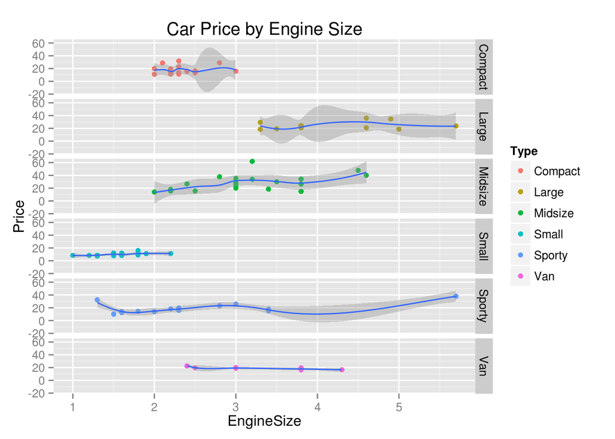

```r
base.two + geom_point(aes(col=Type)) + geom_smooth() + facet_grid (Type ~ .)
```

## Time Series Data

Inherently “continuous”. Data set of interest for exploration: monthly production of beer in Australia.

```r
library (dplyr)
beer <- read.csv("aus-beer.csv")
head(beer)
```

```
##   Year Month beer.megalitres
## 1 1956     1            93.2
## 2 1956     2            96.0
## 3 1956     3            95.2
## 4 1956     4            77.1
## 5 1956     5            70.9
## 6 1956     6            64.8
```

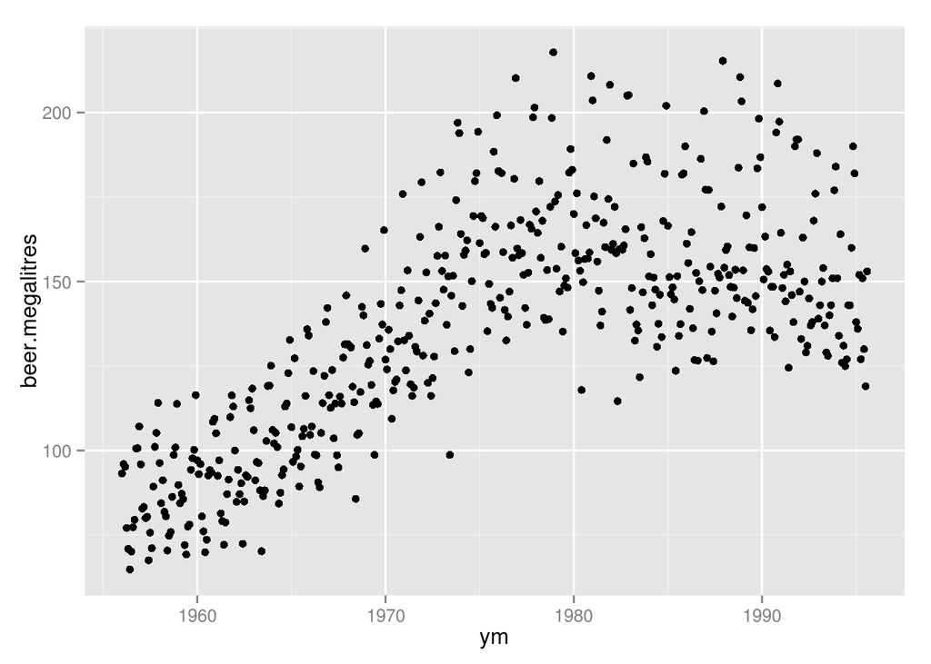

```r
beer <- mutate (beer, ym = Year + Month/12-1/12)

scatter1 <- ggplot (beer, aes (ym, beer.megalitres)) + geom_blank()
scatter1 + geom_point()
```

```
## geom_smooth: method="auto" and size of largest group is <1000, so using loess. Use 'method = x' to change the smoothing method.
```

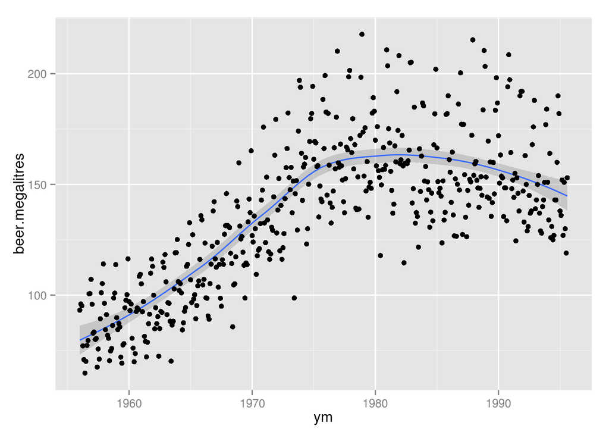

```r
scatter1 + geom_smooth() + geom_point()
```

Another from MASS: Deaths and Serious Injuries of Car Drivers in Great Britain, 1969-1984

```r
head(drivers)
```

```
## [1] 1687 1508 1507 1385 1632 1511
```

```r
class(drivers)
```

```
## [1] "ts"
```

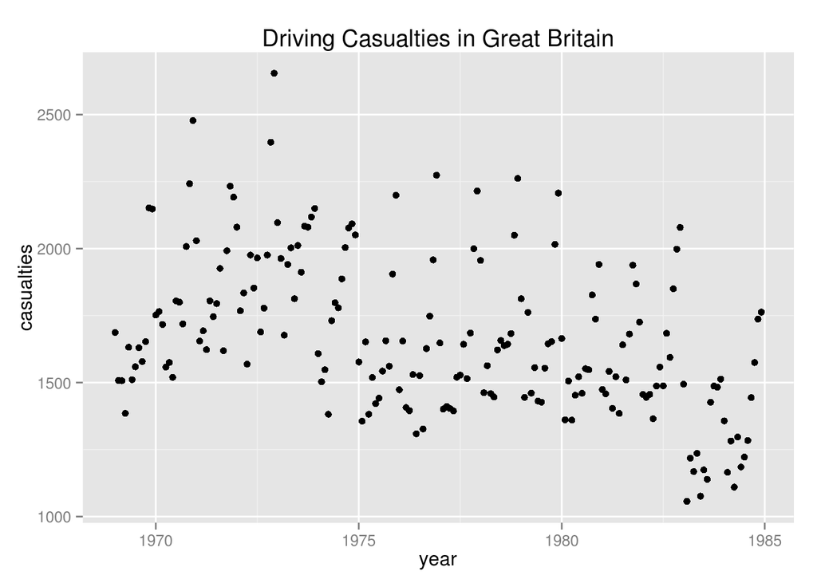

```r
newdrivers <- data.frame (year = time(drivers), casualties = as.vector(drivers)) %>% mutate (month = year - floor(year))

baseplot <- ggplot (newdrivers, aes (year, casualties)) + geom_point() + ggtitle ("Driving Casualties in Great Britain")
baseplot
```

Interesting fact: a mandatory seat belt law was introduced on January 31, 1983. So let’s notate it.

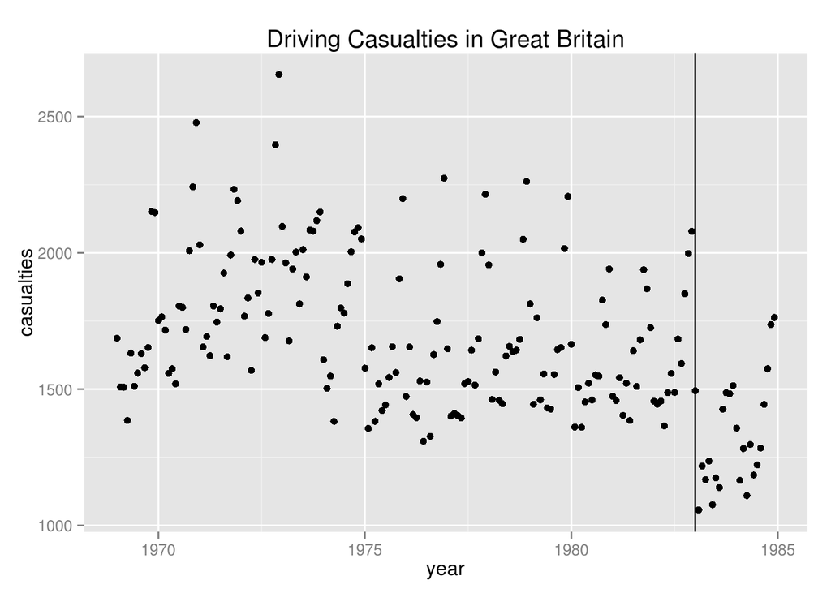

```r
baseplot + geom_vline(xintercept=1983)
```

Is there a seasonal effect?

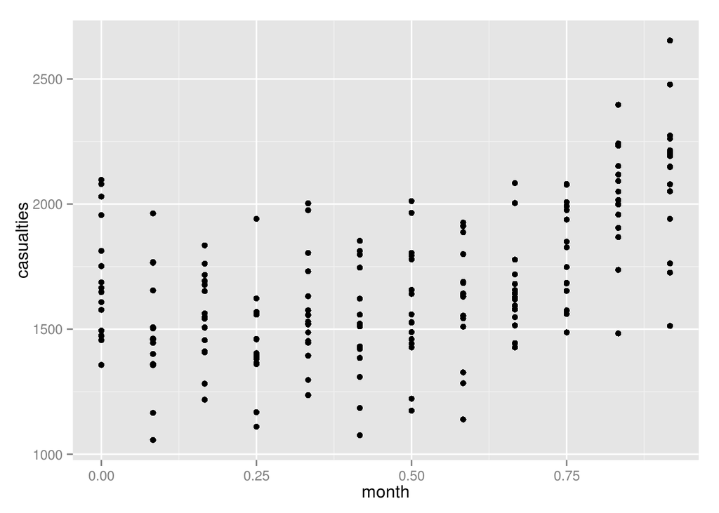

```r
ggplot (newdrivers, aes(month, casualties)) + geom_point()
```

Let’s look at Decembers.

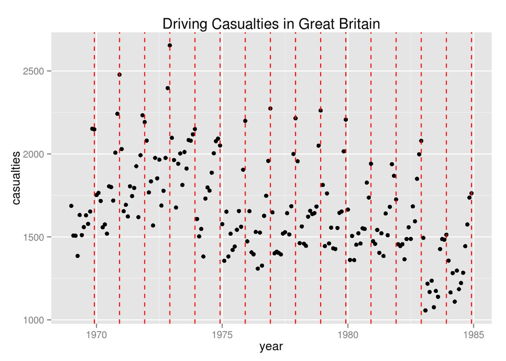

```r
baseplot + geom_vline(aes(xintercept=year[month == max(month)]), col=2, lty=2)
```

Let’s look at a smoother data set with the seatbelt law in place. We have to override the data for each part of the plot.

```
## geom_smooth: method="auto" and size of largest group is <1000, so using loess. Use 'method = x' to change the smoothing method.
## geom_smooth: method="auto" and size of largest group is <1000, so using loess. Use 'method = x' to change the smoothing method.
```

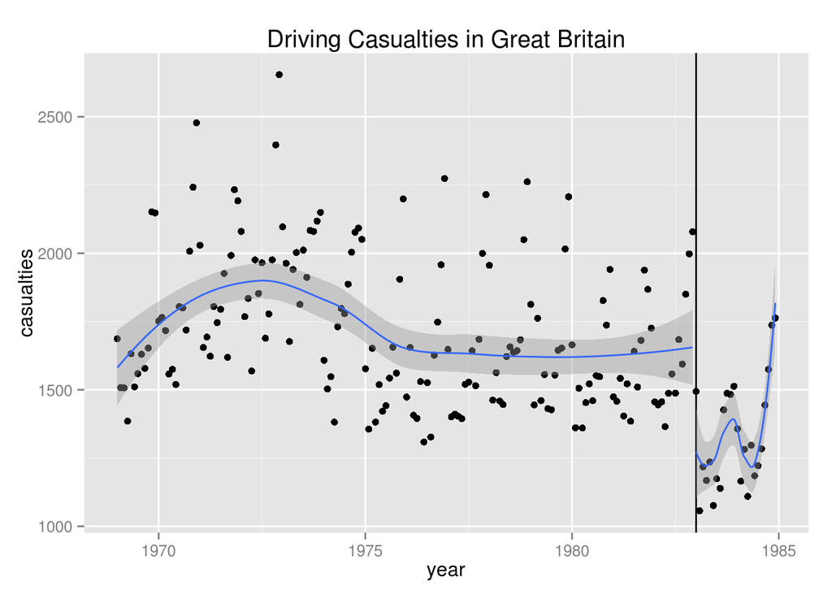

```r
baseplot +
  geom_vline(xintercept=1983) +
  geom_smooth (data=filter (newdrivers, year < 1983)) +
  geom_smooth (data=filter (newdrivers, year >= 1983))
```

## Today’s In-Class Assignment

1. Load the `GSS-extract-2.RData` file from previous classes and assignments.
2. Use `ggplot2` to explore the data – plotting individual columns against each other, adding colors corresponding to variables. In particular:
1. Compare TV behaviour to Radio behaviour in the whole data set. Add facets for marijuana, interracial marriage, gay marriage.
2. Group the data by year and other factors to get the share of demographic variables – the idea being, we will track the acceptance of gay marriage and marijuana legalization over years.
3. Do the same thing with the income achieved per person, using both the ungrouped and grouped data, to see if income changes differ given social attitudes.